# course project1

ma-haoran

2020/12/13

Introduction

It is now possible to collect a large amount of data about personal movement using activity monitoring devices such as a Fitbit, Nike Fuelband, or Jawbone Up. These type of devices are part of the “quantified self” movement – a group of enthusiasts who take measurements about themselves regularly to improve their health, to find patterns in their behavior, or because they are tech geeks. But these data remain under-utilized both because the raw data are hard to obtain and there is a lack of statistical methods and software for processing and interpreting the data.

This assignment makes use of data from a personal activity monitoring device. This device collects data at 5 minute intervals through out the day. The data consists of two months of data from an anonymous individual collected during the months of October and November, 2012 and include the number of steps taken in 5 minute intervals each day.

The data for this assignment can be downloaded from the course web site:

Dataset: Activity monitoring data [52K] The variables included in this dataset are:

steps: Number of steps taking in a 5-minute interval (missing values are coded as NA) date: The date on which the measurement was taken in YYYY-MM-DD format interval: Identifier for the 5-minute interval in which measurement was taken The dataset is stored in a comma-separated-value (CSV) file and there are a total of 17,568 observations in this dataset.

## Q1 What is mean total number of steps taken per day?

1.Read the data

```r
setwd("C:/Users/Apple/Desktop/RStudio Tour/assignment/project5.1")
rawData<-read.csv("activity.csv",header = TRUE)
str(rawData)
```

```
## 'data.frame':    17568 obs. of  3 variables:
##  $ steps   : int  NA NA NA NA NA NA NA NA NA NA ...
##  $ date    : chr  "2012-10-01" "2012-10-01" "2012-10-01" "2012-10-01" ...
##  $ interval: int  0 5 10 15 20 25 30 35 40 45 ...
```

2.transform the date format

```r
library(lubridate)
data<-rawData
data$date<-ymd(data$date)
```

3.histogram of the total number of steps taken each day

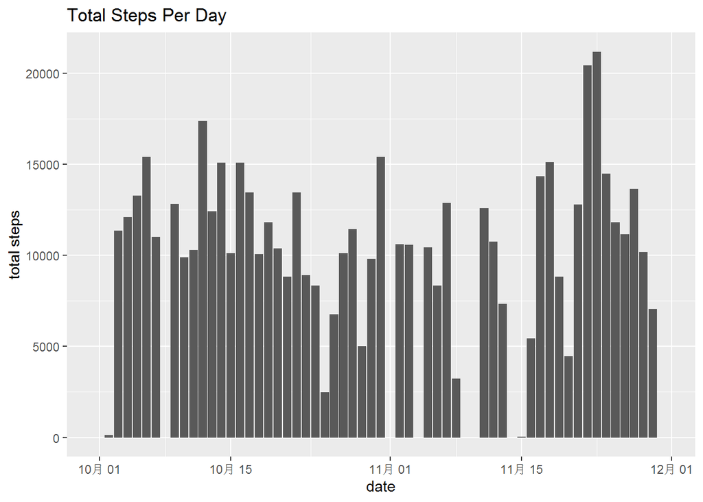

```r
tSteps<-data.frame(
    round(tapply(data$steps,data$date,sum,na.rm=TRUE),2))
colnames(tSteps)<-"total"
tSteps$date<-rownames(tSteps)
rownames(tSteps)<-NULL
tSteps$date<-ymd(tSteps$date)
library(ggplot2)
ggplot(tSteps,aes(x=date,y=total))+geom_bar(
    stat = "identity")+labs(
    x="date",y="total steps",title = "Total Steps Per Day")
```

4. #calculate the mean and median

```r
meanSteps<-mean(tSteps$total)
medianSteps<- median(tSteps$total)
meanSteps
```

```
## [1] 9354.23
```

```r
medianSteps
```

```
## [1] 10395
```

## Q2 What is the average daily activity pattern?

Time series plot of the average number of steps taken

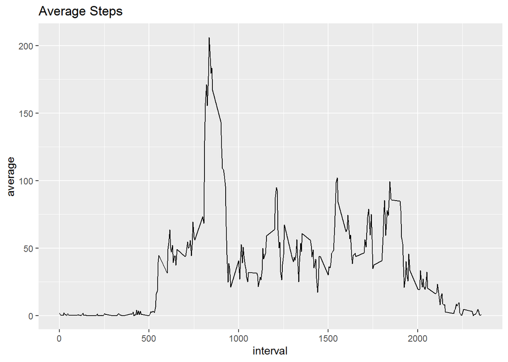

```r
##
averageSteps<-aggregate(data$steps,by=list(data$interval),
                        FUN=mean,na.rm=TRUE)
colnames(averageSteps)<-c("interval","steps")
ggplot(averageSteps,aes(x=interval,y=steps))+geom_line()+labs(
    x="interval",y="average",title = "Average Steps")
```

Which 5-minute interval, on average across all the days in the dataset, contains the maximum number of steps

```r
maxStepsInterval<-averageSteps[which.max(averageSteps$steps),1]
maxStepsInterval
```

```
## [1] 835
```

## Q3 Imputing missing values

Calculate and report the total number of missing values in the dataset

```r
sum(is.na(rawData$steps))
```

```
## [1] 2304
```

Devise a strategy for filling in all of the missing values in the dataset. The strategy does not need to be sophisticated. For example, you could use the mean/median for that day, or the mean for that 5-minute interval, etc.

put the mean for that 5-minute interval to NA

```r
imput_data<-averageSteps$steps[match(rawData$interval,
                                     averageSteps$interval)]
```

Create a new dataset that is equal to the original dataset but with the missing data filled in.

```r
rawData_imputed<-transform(rawData,
                           steps=ifelse(is.na(rawData$steps),
                                             imput_data,rawData$steps))

data2<-aggregate(steps~date, rawData_imputed,sum)

data2<-transform(data2,date=ymd(data2$date))
```

Make a histogram of the total number of steps taken each day

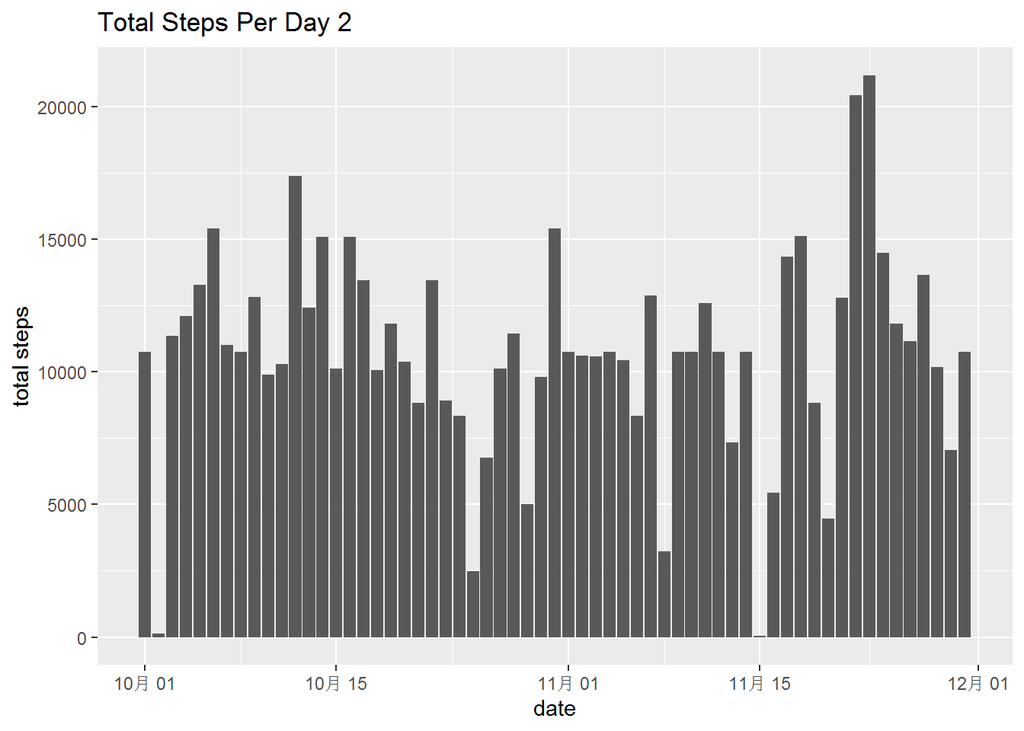

```r
ggplot(data2,aes(date,steps))+geom_bar(stat = "identity")+labs(
    x="date",y="total steps",title = "Total Steps Per Day 2")
```

Calculate and report the mean and median total number of steps taken per day

```r
meanSteps2<-mean(data2$steps)
medianSteps2<-median(data2$steps)
meanSteps2
```

```
## [1] 10766.19
```

```r
medianSteps2
```

```
## [1] 10766.19
```

## Q4 Are there differences in activity patterns between weekdays and weekends?

Create a new factor variable in the dataset with two levels – “weekday” and “weekend” indicating whether a given date is a weekday or weekend day.

```r
rawData_imputed$date<-ymd(rawData_imputed$date)

rawData_imputed$datetype<-sapply(rawData_imputed$date,function(x){
    if(wday(x)==1|wday(x)==7){
      y="weekend"}else{
            y="weekday"}
    y
})

head(rawData_imputed)
```

```
##       steps       date interval datetype
## 1 1.7169811 2012-10-01        0  weekday
## 2 0.3396226 2012-10-01        5  weekday
## 3 0.1320755 2012-10-01       10  weekday
## 4 0.1509434 2012-10-01       15  weekday
## 5 0.0754717 2012-10-01       20  weekday
## 6 2.0943396 2012-10-01       25  weekday
```

Make a panel plot containing a time series plot (i.e. type = “l”) of the 5-minute interval (x-axis) and the average number of steps taken, averaged across all weekday days or weekend days (y-axis).

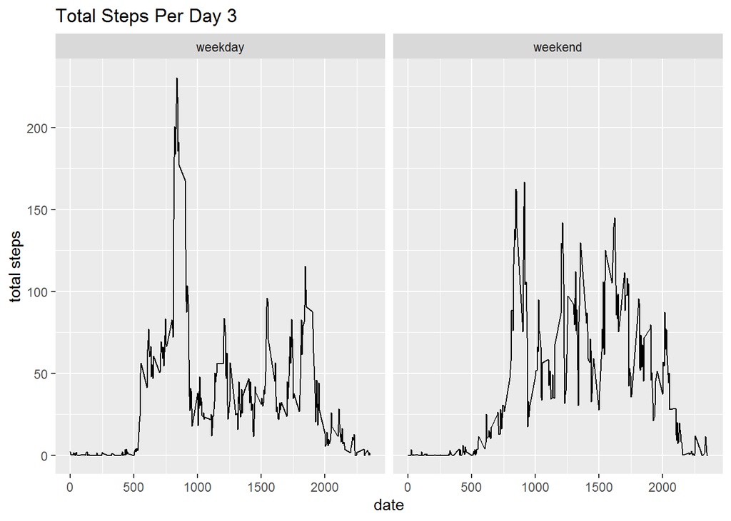

```r
data3<-aggregate(steps~interval+datetype,rawData_imputed,mean)

ggplot(data3,aes(interval,steps))+geom_line()+labs(
    x="date",y="total steps",title = "Total Steps Per Day 3")+facet_grid(.~datetype)
```